# Untitled

Justin Kralick

November 7, 2019

```r
#import data
data_cleaned <- read.csv('data_cleaned.csv', stringsAsFactors = F)

#select variables to consider in model:
data <- tibble(default = data_cleaned$SeriousDlqin2yrs, util = data_cleaned$RevolvingUtilizationOfUnsecuredLines, debtratio = data_cleaned$DebtRatio, income = data_cleaned$MonthlyIncome)



#Split data into train (70%) and test (30%) sets:
smp_size <- floor(0.7 * nrow(data))
set.seed(123) ## set the seed to make partition reproducible
train_ind <- sample(seq_len(nrow(data)), size = smp_size)
train <- data[train_ind, ]
test <- data[-train_ind, ]
```

```r
#fit model, default is our binary response variable measured against the other three variables

model <- glm(default ~ ., data = train, family = binomial)
summary(model)
```

```
##
## Call:
## glm(formula = default ~ ., family = binomial, data = train)
##
## Deviance Residuals:
##     Min       1Q   Median       3Q      Max
## -3.7399  -0.3749  -0.2447  -0.2154   3.9199
##
## Coefficients:
##               Estimate Std. Error  z value Pr(>|z|)
## (Intercept) -3.708e+00  3.613e-02 -102.645  < 2e-16 ***
## util         2.496e+00  3.721e-02   67.073  < 2e-16 ***
## debtratio    8.019e-02  1.370e-02    5.856 4.75e-09 ***
## income      -1.966e-05  3.295e-06   -5.964 2.46e-09 ***
## ---
## Signif. codes:  0 '***' 0.001 '**' 0.01 '*' 0.05 '.' 0.1 ' ' 1
##
## (Dispersion parameter for binomial family taken to be 1)
##
##     Null deviance: 41931  on 82450  degrees of freedom
## Residual deviance: 36558  on 82447  degrees of freedom
## AIC: 36566
##
## Number of Fisher Scoring iterations: 6
```

All variables are statistically significant. Income is negative indicating that the higher the income, the less likely to default. Util and debtratio are positive indicating that the higher the debtratio and the credit utilization, the more likely someone is to default. This is as expected.

```r
anova(model, test= "Chisq")
```

```
## Analysis of Deviance Table
##
## Model: binomial, link: logit
##
## Response: default
##
## Terms added sequentially (first to last)
##
##
##           Df Deviance Resid. Df Resid. Dev  Pr(>Chi)
## NULL                      82450      41931
## util       1   5287.7     82449      36643 < 2.2e-16 ***
## debtratio  1     43.2     82448      36600 4.856e-11 ***
## income     1     42.4     82447      36558 7.479e-11 ***
## ---
## Signif. codes:  0 '***' 0.001 '**' 0.01 '*' 0.05 '.' 0.1 ' ' 1
```

```r
pR2(model)
```

```
##           llh       llhNull            G2      McFadden          r2ML
## -1.827892e+04 -2.096559e+04  5.373342e+03  1.281467e-01  6.309194e-02
##          r2CU
##  1.582686e-01
```

The difference between the deviance and the residual deviance shows how our model is doing against the null model (model with only intercept). The wider this gap, the better. Analyzing the table we can see the drop in deviance when adding each variable one at a time.

To test the accuracy we will use the test data set. R will output probabilities in the form of P(y=1|X). Our decision boundary will be 0.5. If P(y=1|X) > 0.5 then y = 1 otherwise y = 0.

```r
fitted.results <- predict(model,newdata=test,type='response')
fitted.results <- ifelse(fitted.results > 0.5,1,0)

misClasificError <- mean(fitted.results != test$default)
print(paste('Accuracy',1-misClasificError))
```

```
## [1] "Accuracy 0.930158191131109"
```

The accuracy is 0.93 This is a pretty high Accuracy.

Finally, we are going to plot the ROC curve and calculate the area under the curve which are typical performance measurements for logistic. A model with good predictive ability should have an AUC closer to 1 than to 0.5.

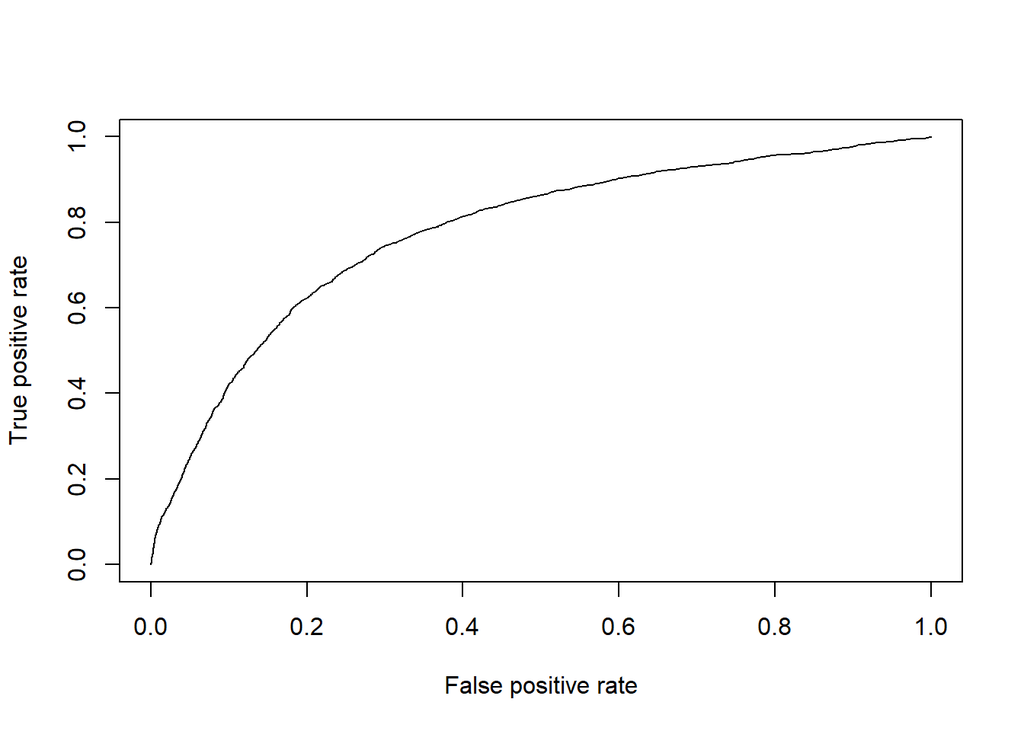

```r
p <- predict(model, newdata=test, type="response")
pr <- prediction(p, test$default)
prf <- performance(pr, measure = "tpr", x.measure = "fpr")
plot(prf)
```

```r
auc <- performance(pr, measure = "auc")
auc <- auc@y.values[[1]]
auc
```

```
## [1] 0.7773334
```